# What factors affect the school readiness of young children?

## Yuri Brunner, Hayden Truong, Kyungje Kim

- Introduction & Motivation:
- Data: Massachusetts Early Care and Education and School Readiness Study
  - Variables
  - Descriptive Statistics
- Visual Examination of Dataset
- Methodology/Empirical Model
- Conclusion
- References

## I) Introduction and Motivation:

Pre-kindergarten programs provide children opportunities for social and cognitive enrichment at a crucial stage of their development. While there's been a broad expansion in both enrollment and funding for early childhood education (ECE) programs across the U.S, the programs that exist vary substantially in both quality and structure. The links between income and academic performance have been well established. Students from lower income families typically score lower on standardized tests and display higher rates of absences across nearly all levels of schooling (Morrissey et. Al 2014). Famines with higher incomes are able to afford private schooling, even as early as pre-k. And it’s currently accepted, and research supports, that these institutions do provide better instruction, with students from private schools begin to outperform their peers as early as grade 4 (Braun et. Al 2006). Whats less understood is what specific elements of ECE programs contribute to the most to academic readiness and future success. How does the program environment play a role? Does the amount of time spent in the program center make a difference? Does the level of enrichment at home play a more significant role?

Our research seeks to fill this gap by analyzing how quality and quantity of enrichment at early childhood education centers and at home, contribute to a child's academic success. Understanding and finding the best way to increase the benefits received from ECE programs is critical for improving the standards for instruction.

## II) Data: Massachusetts Early Care and Education and School Readiness Study

Our data comes from the Massachusetts Early Care and Education and School Readiness Study. Which was conducted between 2001 to 2008, and collected data from 372 children and their families as they progressed through various nonprofit and for-profit ECE programs. The first cohort of students (130) consisted primarily of low-income students in and around the Massachusetts area as was not studied longitudinally, instead data from these students was gathered from a single point in time, subject to when respondents completed their surveys. The second cohort of students (242) were recruited for participation from their previous participation in the Massachusetts Family Income, Infant Child Care, and Child Development Study. Data was collected at intervals of 12 months old, 24 months old, and finally just prior to enrollment in kindergarten. In addition to answering the same survey as the first cohort, this second cohort was also observed inside the classroom, where additional data on school readiness was observed and collected from teachers. Because of these differences in data collection, and for the purpose of gathering the largest dataset possible, our research will focus only on the data collected through the survey, from both cohorts of students.

```python
#load packages
import pandas as pd
import numpy as np
import scipy.stats as stats
from stargazer.stargazer import Stargazer
from IPython.core.display import HTML
import matplotlib.pyplot as plt
import seaborn as sns
import statsmodels.api as sm
import statsmodels.formula.api as smf
import statsmodels.stats.api as sms
from statsmodels.compat import lzip
```

```python
# import excel file and save as new dataset
data = pd.read_excel('/Users/eBay/Desktop/ECON 320/LAB Project /childData.xlsx')
# select variables
data_selectCol = data[["PALS_PK", "INCOMELI_PK", "EDUCAT_PK", "RDDAYWKLI_PK", "TOYTOTAL_PK", "LICCHR_PK", "SELAOVERALL_PK", "ECERSETOTAL_PK", "OVAVERARNETT_PK"]]
#rename variables
data_selectCo2 = data_selectCol.rename(columns={'PALS_PK':'PALS_Score', 'INCOMELI_PK':'Income_Level', 'EDUCAT_PK':'Mother_Education', 'RDDAYWKLI_PK':'RDays_Weekly','TOYTOTAL_PK':'ToyScore_Variety','LICCHR_PK':'Hours_At_Center', 'SELAOVERALL_PK':'CenterScore_Literacy', 'ECERSETOTAL_PK':'CenterScore_Environment', 'OVAVERARNETT_PK':'CenterScore_Caregiver'})
# clean dataset by dropping na values
data_cleaned = data_selectCo2.dropna()
data_cleaned
```

|  | PALS_Score | Income_Level | Mother_Education | RDays_Weekly | ToyScore_Variety | Hours_At_Center | CenterScore_Literacy | CenterScore_Environment | CenterScore_Caregiver |
| --- | --- | --- | --- | --- | --- | --- | --- | --- | --- |
| 0 | 2.125 | 12.0 | 7.0 | 2.0 | 10.0 | 45.0 | 2.89 | 3.46 | 2.3950 |
| 1 | 2.375 | 9.0 | 7.0 | 5.0 | 10.0 | 7.5 | 2.83 | 3.29 | 3.5344 |
| 2 | 1.500 | 10.0 | 6.0 | 5.0 | 11.0 | 32.0 | 2.20 | 3.08 | 2.5406 |
| 4 | 2.000 | 11.0 | 6.0 | 5.0 | 10.0 | 24.0 | 2.24 | 1.58 | 2.6375 |
| 6 | 1.625 | 7.0 | 6.0 | 5.0 | 11.0 | 7.5 | 2.26 | 2.13 | 2.5250 |
| ... | ... | ... | ... | ... | ... | ... | ... | ... | ... |
| 367 | 1.375 | 3.0 | 1.0 | 7.0 | 11.0 | 50.0 | 1.91 | 1.83 | 2.0594 |
| 368 | 1.125 | 3.0 | 2.0 | 5.0 | 11.0 | 33.0 | 1.91 | 1.83 | 2.0594 |
| 369 | 2.000 | 3.0 | 3.0 | 7.0 | 11.0 | 50.0 | 2.44 | 1.63 | 2.9700 |
| 370 | 2.500 | 2.0 | 3.0 | 3.0 | 9.0 | 40.0 | 2.44 | 1.63 | 2.9700 |
| 371 | 1.500 | 8.0 | 3.0 | 4.0 | 11.0 | 40.0 | 2.44 | 1.63 | 2.9700 |

264 rows × 9 columns

### Variables

After cleaning the data frame by excluding study participants who either did not complete or finish their surveys, we are left with 264 observations.  
**Explained Variable: PALS_Score - Academic outcomes: Phonological Awareness and Literacy Screening (PALS) average score**  
Our dependent variable of interest is a child’s PALS_Score or Phonological Awareness and Literacy Screening (PALS) average score. The PALS test is a diagnostic tool used by educators to measure academic fundamentals like alphabet awareness, letter sound knowledge, spelling, word recognition in isolation, and simple oral passage reading. The primary purpose of the PALS test is to identify students display early signs of reading difficulties and who might need additional reading instruction beyond what is being provided through the standard curriculum.By analyzing PALS_Score in conjunction with the independent variables below, we will be able to asses the factors that affect school readiness as well as their magnitude.

**Explanatory Variables:**  
*INCOME_Level* - Total family's income level (USD), as measured by the scale below.

> (1: Less than 10,000, 2: 10,001-20,000, 3: 20,001-30,000, ..., 10: 90,001-100,000,  
> 11: 100,001-150,000, 12: 150,001-200,000, 13: More than 200,000)

*EDUCAT_PK* - Mother's education level, as measured by the scale below.

> (1: Some high school, 2: High school, 3: Some college,4: Associate degree, 5: Technical school,  
> 6: Bachelor degree, 7: Graduate degree)

*RDays_Weekly* - Number of days in each week that parents read children's books to their child at home.  
*ToyScore_Variety* - Score for the variety of toys in the child's home.  
*Hours_At_Center* - Number of hours in each week that a child spends at the education center.  
*CenterScore_Literacy* - Center quality score: Support for Early Literacy Assessment  
*CenterScore_Environment* - Center quality score: Environment Rating on Early Childhood Development  
*CenterScore_Caregiver* - Center quality score: Arnett Caregiver Interaction Scale average score

### Descriptive Statistics

```python
# descriptive statistics
table = data_cleaned.describe()
table
```

|  | PALS_Score | Income_Level | Mother_Education | RDays_Weekly | ToyScore_Variety | Hours_At_Center | CenterScore_Literacy | CenterScore_Environment | CenterScore_Caregiver |
| --- | --- | --- | --- | --- | --- | --- | --- | --- | --- |
| count | 264.000000 | 264.000000 | 264.000000 | 264.000000 | 264.000000 | 264.000000 | 264.000000 | 264.000000 | 264.000000 |
| mean | 2.039837 | 7.318182 | 4.742424 | 5.303030 | 10.268939 | 30.133523 | 2.725189 | 2.665000 | 2.899103 |
| std | 0.501254 | 3.964324 | 1.932792 | 1.843453 | 1.067860 | 13.843896 | 0.600994 | 0.834652 | 0.360823 |
| min | 1.000000 | 1.000000 | 1.000000 | 0.000000 | 4.000000 | 2.500000 | 1.290000 | 1.170000 | 1.993800 |
| 25% | 1.625000 | 3.000000 | 3.000000 | 4.000000 | 10.000000 | 16.000000 | 2.347500 | 2.130000 | 2.695325 |
| 50% | 2.125000 | 7.500000 | 6.000000 | 5.500000 | 11.000000 | 35.000000 | 2.635000 | 2.560000 | 2.948450 |
| 75% | 2.500000 | 11.000000 | 6.000000 | 7.000000 | 11.000000 | 40.000000 | 3.110000 | 3.140000 | 3.143800 |
| max | 2.750000 | 13.000000 | 7.000000 | 7.000000 | 11.000000 | 50.000000 | 4.600000 | 5.460000 | 3.743800 |

## III) Visual Examination of Dataset

```
 (PALS) Score by Income Level
```

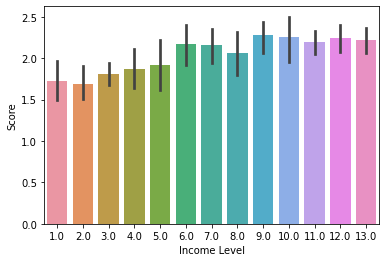

```python
academicIncomeL = sns.barplot(x="Income_Level", y="PALS_Score", data=data_cleaned)
academicIncomeL.set(xlabel="Income Level", ylabel="Score");
print('\n (PALS) Score by Income Level\n',)
```

The bar graph above displays mean PALS score for each income level. The results reveal what appears to be a week positive relationship between income level and PALS score. The effect of income also appears to display diminishing margin returns beyond level 6 or above $60,000 USD in annual income.

```
 (PALS) Score by Income Level
```

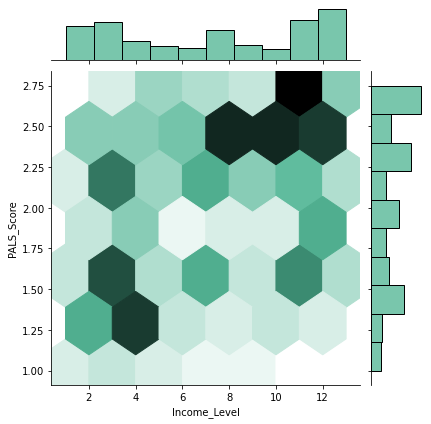

```python
x = data_cleaned["Income_Level"]
y = data_cleaned["PALS_Score"]
sns.jointplot(x=x, y=y, kind="hex", color="#4CB391");
print('\n (PALS) Score by Income Level\n',)
```

The joint plot above also displays mean PALS score for each income level, however the hexbin as the well as histograms along each axis display the relationship much better. We can clearly see tight clusters of data points in both the top right and bottom left corners of the graphs, along with peaks on the corresponding histograms. This suggests that within our sample students from families with higher incomes score better on the PALS test than students from families with lower incomes. More analysis needs to be conducted to determine if this relationship is statistically significant or not, as we can also see from the graph, this does not appear to be true for all students.

```
 (PALS) Score by Mothers education level
```

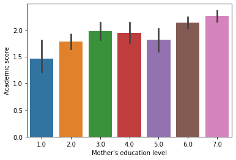

```python
parentEduct = sns.barplot(x="Mother_Education", y="PALS_Score", data=data_cleaned)
parentEduct.set(xlabel="Mother's education level", ylabel="Academic score");
print('\n (PALS) Score by Mothers education level \n',)
```

```
 (PALS) Score by Mothers education level
```

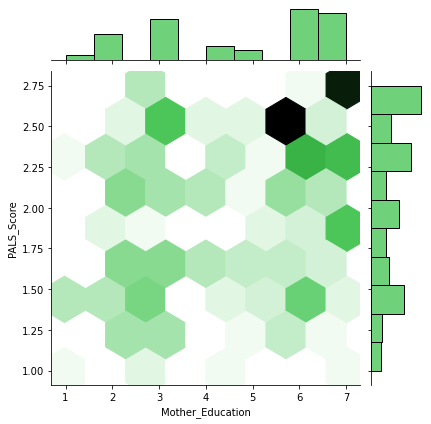

```python
x = data_cleaned["Mother_Education"]
y = data_cleaned["PALS_Score"]
sns.jointplot(x=x, y=y, kind="hex", color="#3FC44E");
print('\n (PALS) Score by Mothers education level \n',)
```

The charts above display mean PALS score by mother’s education level. While a relativity weak positive relationship can be seen in the bar graph, with average score increasing alongside mother’s education level, our joint plot which better factors for our data’s distribution, tells a slightly different story. From the hexbin plot we can clearly a wide range in PALS scores among students who’s mothers posses either a bachelors or graduate degree (levels 6 & 7). We can also see students who’s mothers have little to no college education (levels 1,2 & 3) outperforming those who’s mothers do. All of this suggests that within our sample mothers education level is at best weakly positively correlated.

```
 (PALS) Score by Number of days in each week that parents read books to their child
```

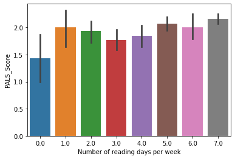

```python
academicReadD = sns.barplot(x="RDays_Weekly", y="PALS_Score", data=data_cleaned)
academicReadD.set(xlabel="Number of reading days per week", ylabel="PALS_Score");

print('\n (PALS) Score by Number of days in each week that parents read books to their child \n',)
```

```
 (PALS) Score by Number of days in each week that parents read books to their child
```

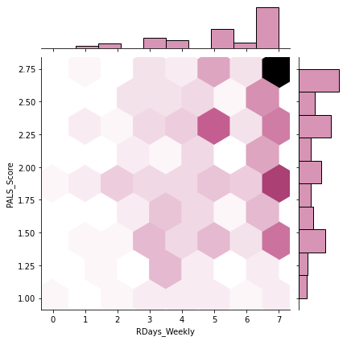

```python
x = data_cleaned["RDays_Weekly"]
y = data_cleaned["PALS_Score"]
sns.jointplot(x=x, y=y, kind="hex", color="#CA709C");
print('\n (PALS) Score by Number of days in each week that parents read books to their child \n',)
```

The two charts above display PALS score by the number of days in each week that a parent reads children’s books to their child while at home. The bar graph suggests that any reading is beneficial for a child’s academic development, as shown by the large increase in PALS score for any number of days per week larger than zero. Again our joint plot provides a clearer picture of what might really be going on. Our histogram for reading days per week shows us that almost all parents recognize reading as beneficial for their Childs development, with the vast majority of parents reading to their child at least five days a week. However the effect this has on PALS score is less clear. Although we see a very distant cluster in the top right corner of our hexbin plot, suggesting a strong positive relationship we can just as clearly see a wide range in scores among students receiving the same among of reading time.

```
 (PALS) Score by the number of different toys at home
```

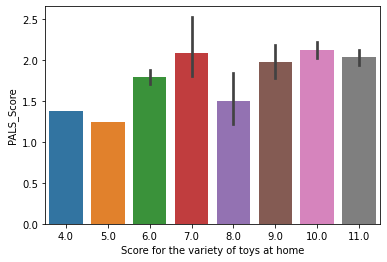

```python
academicToy = sns.barplot(x="ToyScore_Variety", y="PALS_Score", data=data_cleaned)
academicToy.set(xlabel="Score for the variety of toys at home", ylabel="PALS_Score");
print('\n (PALS) Score by the number of different toys at home\n',)
```

```
 (PALS) Score by the number of different toys at home
```

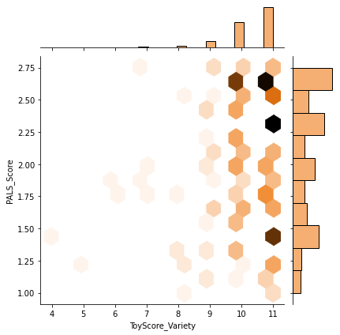

```python
x = data_cleaned["ToyScore_Variety"]
y = data_cleaned["PALS_Score"]
sns.jointplot(x=x, y=y, kind="hex", color="#F29544");
print('\n (PALS) Score by the number of different toys at home\n',)
```

The two charts above display PALS score by the variety of toys the child has at home. Variety was assessed through self reporting on the survey. With parents responding yes or no to each type of toy listed as a possible response. Examples of types of toys include but were not limited to, board games, building blocks, coloring books etc. Any significant relationship one way or the other is hard to see from the bar graph, it appears that a higher variety of toys leads to higher PALS scores, but that this effect diminishes significantly after more than 5 or 6 different toys are present. The hexbin plot and histograms show us that a vast marjory of households have at least 9 different toys, and the affect this has on PALS scores is likely insignificant, as shown by the wide range in PALS score among students with any number fo toys at home.

```
 (PALS) Score by the number of hours each week spent at center
```

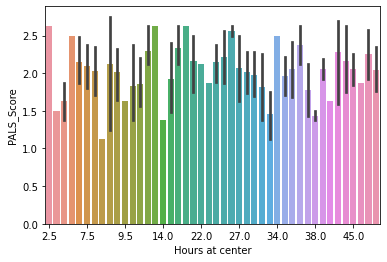

```python
academicCenterHr = sns.barplot(x="Hours_At_Center", y="PALS_Score", data=data_cleaned)
academicCenterHr.set(xlabel="Hours at center", ylabel="PALS_Score");
plt.xticks([0, 5, 10,15,20,25,30,35,40]);
print('\n (PALS) Score by the number of hours each week spent at center\n',)
```

```
 Regression of (PALS) Score on the number of hours each week spent at center
```

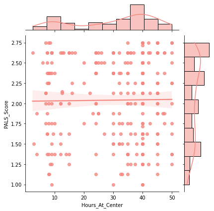

```python
x = data_cleaned["Hours_At_Center"]
y = data_cleaned["PALS_Score"]
sns.jointplot(x=x, y=y, kind="reg", color="#F58982");
print('\n Regression of (PALS) Score on the number of hours each week spent at center\n',)
```

The two charts above display PALS score by the number of hours each week spent a child spends at their early education center. We observe what appears to be an almost random distribution in both variables. And our scatterplot with linear regression shows almost no relationship at all. This comes at a surprise, as research suggests that increasing the number of hours and overall exposure to education materials in during early childhood development leads to better education outcomes. More needs to be done to determine if our results are significant or not, but it appears at least now that the amount of time spent in early education has little to no effect on PALS score within our sample.

```
 Regression of (PALS) Score on Center quality score for Early Literacy Development
```

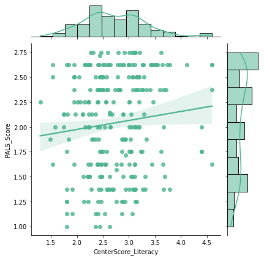

```python
x = data_cleaned["CenterScore_Literacy"]
y = data_cleaned["PALS_Score"]
sns.jointplot(x=x, y=y, kind="reg", color="#4CB391");
print('\n Regression of (PALS) Score on Center quality score for Early Literacy Development\n',)
```

The joint plot above shows the liner regression between a student’s PALS score and the Center quality score it received in the category “support for Early Literacy Assessment”. The quality score combines a number of metrics used to asses a center’s curriculum in regards to preparing students for literacy assessment. We observe an approximately normal distribution in the quality scores given to early education centers, and a positive relationship between PALS score and centers that score higher.

```
 Regression of (PALS) Score on Center Enviromnet Score for Ealry Childhood development
```

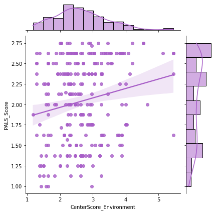

```python
x = data_cleaned["CenterScore_Environment"]
y = data_cleaned["PALS_Score"]
sns.jointplot(x=x, y=y, kind="reg", color="#A75DC7")
print('\n Regression of (PALS) Score on Center Enviromnet Score for Ealry Childhood development \n',);
```

The joint plot above shows the liner regression between a student’s PALS score and the Center quality score it received in the category “Environment Rating on Early Childhood Development”. The quality score combines a number of metrics used to asses a center’s environment and the level of enrichment and external stimuli present. We observe an approximately normal distribution in the scores given to early education centers, and a positive relationship between PALS score and centers that score higher.

```
 Regression of (PALS) Score on Center Quality Score for Caregiver Interaction
```

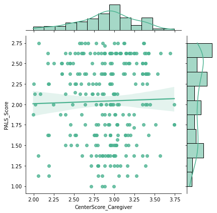

```python
x = data_cleaned["CenterScore_Caregiver"]
y = data_cleaned["PALS_Score"]
sns.jointplot(x=x, y=y, kind="reg", color="#4CB391");
print('\n Regression of (PALS) Score on Center Quality Score for Caregiver Interaction \n',);
```

The joint plot above shows the liner regression between a student’s PALS score and the Center quality score it received for its caregivers. The Arnett Caregiver Interaction Scale combines a number of metrics used to how educators interact with young children. Teachers were observed inside the classroom during normal instruction and assed on a scale from 1-4 (1=not true at all, 4= very much true). Examples of interactions assessed include; encouraging the children to try new experiences, speaking warmly to the children or being harsh when scolding or prohibiting children from activities. We observe an approximately normal distribution in the scores given to caregivers and their interactions with students, an no clear relationship one way or the other from our regression.

## III) Methodology/Empirical Model

Given the current literature surrounding the topic of early education programs, and the variables available to us in our data set we have developed the following regression equation:

*Academic Score = b0 + b1*Income Level + b2*Mother's Education Level + b3*Number of Reading Days + b4*Score for Toys + b5*Hours at Center + b6*SELA Score + b7*ECERS Score + b8*Arnett Score*

Our model takes into account a wide variety of data, from specific measures of ECE program quality to measures of family socioeconomic status like income and maternal education. While current research suggests that each of the variables listed below will each be positively correlated with a child’s PALS_Score, we are more interested in accessing the coefficients and their magnitude’s to better understand which of these variables has the largest affect.

Our hypotheses are as follows:

1. As family's income level increases, PALS score of child increases
2. As mother's education level increases, PALS score of child increases
3. As number of reading days in each week increases, PALS score of child increases
4. As score for number of toys increases, PALS score of child increases
5. As the number of hours spent at center each week increases, PALS score of child increases
6. As Center Literacy Score increases, PALS score of child increases
7. As Center Environment Score increases, PALS score of child increases
8. As Center Caregiver Score increases, PALS score of child increases
9. As scores for center quality increase together, PALS score of child increases

```python
corr_matrix = data_cleaned.corr()
print(round(corr_matrix, 3))
```

```
                         PALS_Score  Income_Level  Mother_Education  \
PALS_Score                    1.000         0.381             0.344
Income_Level                  0.381         1.000             0.737
Mother_Education              0.344         0.737             1.000
RDays_Weekly                  0.251         0.376             0.305
ToyScore_Variety              0.126         0.207             0.168
Hours_At_Center               0.012        -0.036            -0.022
CenterScore_Literacy          0.108         0.024             0.011
CenterScore_Environment       0.192         0.203             0.120
CenterScore_Caregiver         0.025        -0.115            -0.085

                         RDays_Weekly  ToyScore_Variety  Hours_At_Center  \
PALS_Score                      0.251             0.126            0.012
Income_Level                    0.376             0.207           -0.036
Mother_Education                0.305             0.168           -0.022
RDays_Weekly                    1.000             0.316            0.035
ToyScore_Variety                0.316             1.000            0.012
Hours_At_Center                 0.035             0.012            1.000
CenterScore_Literacy            0.105            -0.033           -0.059
CenterScore_Environment         0.162             0.048           -0.067
CenterScore_Caregiver          -0.004            -0.043           -0.086

                         CenterScore_Literacy  CenterScore_Environment  \
PALS_Score                              0.108                    0.192
Income_Level                            0.024                    0.203
Mother_Education                        0.011                    0.120
RDays_Weekly                            0.105                    0.162
ToyScore_Variety                       -0.033                    0.048
Hours_At_Center                        -0.059                   -0.067
CenterScore_Literacy                    1.000                    0.714
CenterScore_Environment                 0.714                    1.000
CenterScore_Caregiver                   0.672                    0.426

                         CenterScore_Caregiver
PALS_Score                               0.025
Income_Level                            -0.115
Mother_Education                        -0.085
RDays_Weekly                            -0.004
ToyScore_Variety                        -0.043
Hours_At_Center                         -0.086
CenterScore_Literacy                     0.672
CenterScore_Environment                  0.426
CenterScore_Caregiver                    1.000
```

Next, we will run regressions including different variables to see if there is a significant relationship between any of our variables as well as sufficient evidence to support our hypotheses.

```python
# set each regression
m1 = smf.ols(formula = "PALS_Score ~ Income_Level", data=data_cleaned).fit()
m2 = smf.ols(formula = "PALS_Score ~ Income_Level + Mother_Education", data=data_cleaned).fit()
m3 = smf.ols(formula = "PALS_Score ~ Income_Level + Mother_Education + RDays_Weekly", data=data_cleaned).fit()
m4 = smf.ols(formula = "PALS_Score ~ Income_Level + Mother_Education + RDays_Weekly + ToyScore_Variety", data=data_cleaned).fit()
m5 = smf.ols(formula = "PALS_Score ~ Income_Level + Mother_Education + RDays_Weekly + ToyScore_Variety + Hours_At_Center", data=data_cleaned).fit()
m6 = smf.ols(formula = "PALS_Score ~ Income_Level + Mother_Education + RDays_Weekly + ToyScore_Variety + Hours_At_Center + CenterScore_Literacy", data=data_cleaned).fit()
m7 = smf.ols(formula = "PALS_Score ~ Income_Level + Mother_Education + RDays_Weekly + ToyScore_Variety + Hours_At_Center + CenterScore_Literacy + CenterScore_Environment", data=data_cleaned).fit()
m8 = smf.ols(formula = "PALS_Score ~ Income_Level + Mother_Education + RDays_Weekly + ToyScore_Variety + Hours_At_Center + CenterScore_Literacy + CenterScore_Environment + CenterScore_Caregiver", data=data_cleaned).fit()
```

```python
# view the results using a stargazer table
st = Stargazer([m1, m2, m3, m4, m5, m6, m7, m8])
st = Stargazer([m1,m2,m3,m4,m5,m6,m7,m8])
st.covariate_order(['Intercept','Income_Level', 'Mother_Education', 'RDays_Weekly','ToyScore_Variety','Hours_At_Center','CenterScore_Literacy' ,'CenterScore_Environment','CenterScore_Caregiver'])
from IPython.core.display import HTML
HTML(st.render_html())
```

|  | *Dependent variable:PALS_Score* |  |  |  |  |  |  |  |
| --- | --- | --- | --- | --- | --- | --- | --- | --- |
|  | (1) | (2) | (3) | (4) | (5) | (6) | (7) | (8) |
| Intercept | 1.688*** | 1.612*** | 1.484*** | 1.406*** | 1.386*** | 1.153*** | 1.182*** | 1.140*** |
|  | (0.060) | (0.076) | (0.099) | (0.278) | (0.284) | (0.318) | (0.319) | (0.379) |
| Income_Level | 0.048*** | 0.035*** | 0.030*** | 0.030*** | 0.030*** | 0.030*** | 0.027** | 0.028** |
|  | (0.007) | (0.011) | (0.011) | (0.011) | (0.011) | (0.011) | (0.011) | (0.011) |
| Mother_Education |  | 0.036 | 0.034 | 0.034 | 0.034 | 0.034 | 0.036 | 0.036 |
|  |  | (0.022) | (0.022) | (0.022) | (0.022) | (0.022) | (0.022) | (0.022) |
| RDays_Weekly |  |  | 0.033** | 0.032* | 0.031* | 0.028 | 0.027 | 0.028 |
|  |  |  | (0.017) | (0.017) | (0.017) | (0.017) | (0.017) | (0.017) |
| ToyScore_Variety |  |  |  | 0.008 | 0.008 | 0.012 | 0.010 | 0.010 |
|  |  |  |  | (0.028) | (0.028) | (0.028) | (0.028) | (0.028) |
| Hours_At_Center |  |  |  |  | 0.001 | 0.001 | 0.001 | 0.001 |
|  |  |  |  |  | (0.002) | (0.002) | (0.002) | (0.002) |
| CenterScore_Literacy |  |  |  |  |  | 0.077 | 0.019 | 0.009 |
|  |  |  |  |  |  | (0.048) | (0.069) | (0.084) |
| CenterScore_Environment |  |  |  |  |  |  | 0.060 | 0.060 |
|  |  |  |  |  |  |  | (0.051) | (0.051) |
| CenterScore_Caregiver |  |  |  |  |  |  |  | 0.022 |
|  |  |  |  |  |  |  |  | (0.109) |
| Observations | 264 | 264 | 264 | 264 | 264 | 264 | 264 | 264 |
| R<sup>2</sup> | 0.145 | 0.154 | 0.166 | 0.166 | 0.167 | 0.175 | 0.180 | 0.180 |
| Adjusted R<sup>2</sup> | 0.142 | 0.147 | 0.156 | 0.153 | 0.151 | 0.156 | 0.157 | 0.154 |
| Residual Std. Error | 0.464 (df=262) | 0.463 (df=261) | 0.460 (df=260) | 0.461 (df=259) | 0.462 (df=258) | 0.461 (df=257) | 0.460 (df=256) | 0.461 (df=255) |
| F Statistic | 44.380*** (df=1; 262) | 23.670*** (df=2; 261) | 17.255*** (df=3; 260) | 12.918*** (df=4; 259) | 10.323*** (df=5; 258) | 9.095*** (df=6; 257) | 8.008*** (df=7; 256) | 6.986*** (df=8; 255) |
| Note: | *p<0.1; **p<0.05; ***p<0.01 |  |  |  |  |  |  |  |

Before we interpret the T-test results for significance we need to check for heteroskedasticity. The null is there is no heteroskedasticity present in the model.

```python
test = sms.het_breuschpagan(m8.resid, m8.model.exog)
name = ['Lagrange Multiplier statistic','p-value','f-value','f p-value']
pd.DataFrame(lzip(name,test))
```

|  | 0 | 1 |
| --- | --- | --- |
| 0 | Lagrange Multiplier statistic | 9.824631 |
| 1 | p-value | 0.277551 |
| 2 | f-value | 1.232063 |
| 3 | f p-value | 0.280527 |

At alpha = 0.05, we notice that only the income factor and intercept show consistently statistically significant results. We fail to reject the null that other variables are statistically insignificant, meaning that they might not have an effect on school performance among the studied subjects. We will then test the joint significance of the variables (excluding income) by taking an F-test.

```python
hypotheses = ['Mother_Education=0', 'RDays_Weekly=0','ToyScore_Variety=0','Hours_At_Center=0','CenterScore_Literacy=0','CenterScore_Environment=0','CenterScore_Caregiver=0']
m8_hc3 = smf.ols(formula = "PALS_Score ~ Income_Level + Mother_Education + RDays_Weekly + ToyScore_Variety + Hours_At_Center + CenterScore_Literacy + CenterScore_Environment + CenterScore_Caregiver", data=data_cleaned).fit(cov_type='HC3')
ftest_hc3 = m8_hc3.f_test(hypotheses)
fstat_hc3 = ftest_hc3.statistic[0][0]
fpval_hc3 = ftest_hc3.pvalue
print(f'fstat_hc3: {np.around(fstat_hc3, 5)}\n')
print(f'fpval_hc3: {np.around(fpval_hc3,10)}\n')
```

```
fstat_hc3: 1.64099

fpval_hc3: 0.1242566251
```

We achieve a low F-statistic and high P-value (>0.05) for the F-test. We fail to reject the null that the all of our variables are statistically insignificant.

```python
m8.compare_f_test(m1)
```

```
(1.5503631426837057, 0.15076789814216354, 7.0)
```

```python
hypotheses2 = ['CenterScore_Literacy=0','CenterScore_Environment=0','CenterScore_Caregiver=0']
m8_hc3 = smf.ols(formula = "PALS_Score ~ Income_Level + Mother_Education + RDays_Weekly + ToyScore_Variety + Hours_At_Center + CenterScore_Literacy + CenterScore_Environment + CenterScore_Caregiver", data=data_cleaned).fit(cov_type='HC3')
ftest2_hc3 = m8_hc3.f_test(hypotheses2)
fstat2_hc3 = ftest_hc3.statistic[0][0]
fpval2_hc3 = ftest_hc3.pvalue
print(f'fstat2_hc3: {np.around(fstat2_hc3, 5)}\n')
print(f'fpval2_hc3: {np.around(fpval2_hc3,10)}\n')
```

[output not shown]

In our second F-test we also achieve a low F-statistic and high P-value (>0.05). From these results we fail to reject the null hypothesis that higher ECE program quality ratings collectively have no effect on a child’s PALS performance.

## IV) Conclusion

In conclusion, we can not say that any of our variables, aside from income have any statistically significant affect on a child’s PALS score. This comes as a surprise, research suggested that our variables, which encompassed factors both inside and outside of the ECE program would each have a positive effect. And a while each of our regression coefficients was indeed positive, none aside from our intercept and coefficient for income where significant using an alpha of 0.05 in our final model.

Knowing that income does have an effect next raises the question of how. How and through what channels does economic capital have to flow through in order to create positive outcomes in early education? Or correlation matrix reveals that income is positively correlated with the ratings for ECE environment, as well as the scores for the variety of toys at home and the amount of reading time a child the receives. This intuitively makes sense, famines with higher incomes can afford to send their child to ’better’ private ECE programs, as well as provide more enrichment at home. But the results from our regression show us that both of these factors have little to no effect. More so our results from our second F-test show us that ECE programs that rank higher in quality are no more likely to improve a child’s PALS performance.

Overall our results reveal more questions than they answer, but it’s worth noting a few limitations to our design that might have impacted our results. The first has to do with sample size and selection. After data cleaning we were left with only 264 usable observations and ideally we would have many hundred, if not thousands more, that included data from outside of the Massachusetts area. We advocate for a larger study, with a broader scope of both participants and survey questions. Such a study could find that some of the variables we included here are indeed significant, and if it’s findings would be more generalizable to ECE programs across the country, not just those in and around the Massachusetts area.

## V) References

Marshall, Nancy, Roberts, Joanne, and Wagner Robeson, Wendy. Massachusetts Early Care and Education and School Readiness Study, 2001-2008. Inter-university Consortium for Political and Social Research [distributor], 2013-04-05. https://doi.org/10.3886/ICPSR33968.v1

Morrissey, T. W., Hutchison, L., & Winsler, A. (2014). Family income, school attendance, and academic achievement in elementary school. Developmental psychology, 50(3), 741–753. https://doi.org/10.1037/a0033848

Braun, H., Jenkins, F., and Grigg, W. (2006). Comparing Private Schools and Public Schools Using Hierarchical Linear Modeling (NCES 2006-461). U.S. Department of Education, National Center for Education Statistics, Institute of Education Sciences. Washington, DC: U.S. Government Printing Office.